# Sociología del Género

SOL3061 | Clase 3. Nivel meso: interacciones

Tania Hutt

## Memo de preguntas de investigación

- Fecha de entrega: **viernes 23 de octubre** a las 23:59 por Canvas.
- Extensión: **1 página**, espacio simple.
- Contenido:
  1. 2 o 3 preguntas de investigación candidatas, enmarcadas en la sociología del género.
  2. Para cada una, 1 o 2 frases sobre por qué importa: qué problema, debate o vacío aborda.
- No se requiere un diseño de investigación.
- Se evalúa como completo o incompleto, con retroalimentación breve para ayudarles a elegir y afinar la pregunta.
- Siguiente etapa: **mapa crítico de literatura** (viernes 6 de noviembre).

## Del nivel micro al nivel meso

- Clase 2: el género se **incorpora** en cuerpos e identidades.
- Hoy: el género se **produce en la interacción**, aunque no lo hayamos internalizado.

**Puzzle:** si las diferencias individuales entre hombres y mujeres son pequeñas (Zell et al. 2015), ¿por qué la desigualdad de género es tan persistente?

## Hoja de ruta

#### 1. Hacer género

El género como logro interaccional.

→

#### 2. Creencias y estatus

Cuándo y cuánto pesa el género.

→

#### 3. Interseccionalidad

¿De qué hombres y mujeres hablan estas teorías?

→

#### 4. Experiencias trans

Lo que revelan sobre el sistema de género.

# Hacer género

## Normas y expectativas de género

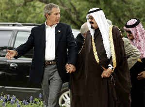

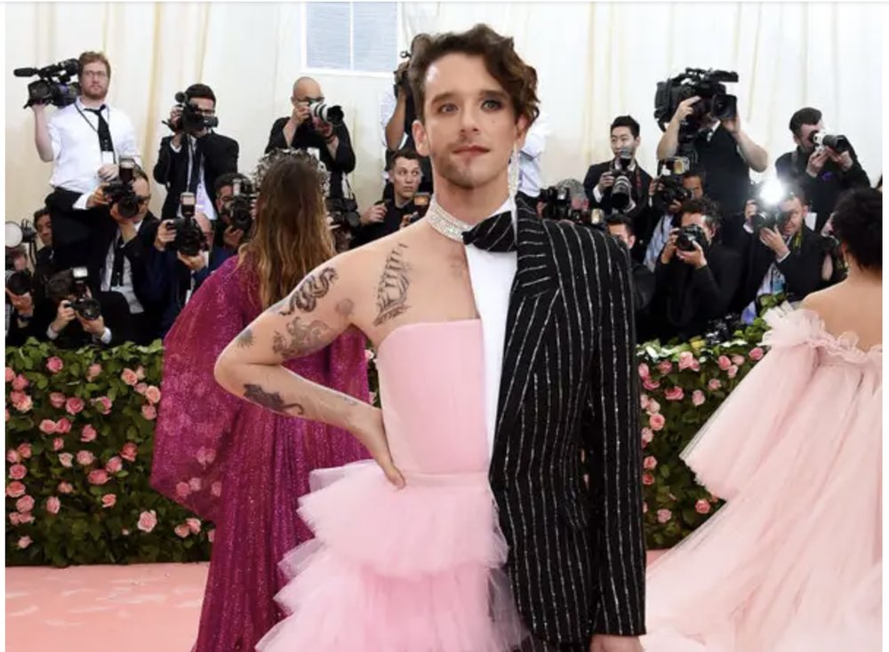

- El género lo “hacemos” en la medida que obedecemos o rompemos reglas y expectativas de género.
- Es la manera en que el género como constructo social se refuerza en la interacción social.
- Hay variación contextual, cultural, y temporal de las normas de género.

## Teorías de “hacer género”

- “Sostenemos que el ‘hacer género’ es realizado por mujeres y hombres cuya competencia como miembros de la sociedad es rehén de su producción”.
- El género es algo que uno hace, más que algo que uno es.
- “Hacer género significa crear diferencias entre niños y niñas y hombres y mujeres, diferencias que no son naturales, esenciales o biológicas. Una vez que las diferencias han sido construidas, se utilizan para reforzar la ‘esencialidad’ de género.” (West y Zimmerman).
- ¿Ejemplos de “hacer género”?

## Tres distinciones analíticas

(West y Zimmerman 1987)

**Sexo**

Criterios biológicos socialmente acordados.

**Categoría de sexo**

Clasificación cotidiana por señales visibles que se *presume* reflejan el sexo.

**Género**

Conducta gestionada según lo apropiado para cada categoría.

- Clave: **rendición de cuentas** (*accountability*). Por eso no es posible “no hacer género”.

## ¿Por qué “hacemos género”?

(Wade & Max Ferree 2023)

- Por **hábito**: lo hemos “sobre aprendido”.
- Por **placer**: “performar bien” el género puede ser gratificante.
- Por **otras personas**: depende de la audiencia.
- Para evitar la **fiscalización**: quien no sigue las normas es castigado (“niñita”, “mandona”).
- Las normas se rompen todo el tiempo, de manera incidental o intencional.

## Hacer género no binario

- Es un desafío ser visto como no binario en un mundo de género binario, y muchas veces implica mezclar lo femenino con lo masculino.
- “Quiero que las personas me miren y no piensen que soy hombre o mujer. Si están confundidos, ese es el punto.” (Kline, en Wade & Max Ferree 2023)

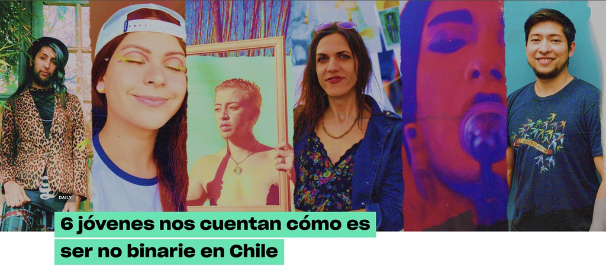

## Diferencias entre socialización y “hacer género”

- Ambos enfoques reconocen creencias y expectativas de género diferenciadas.
- Difieren en si esas expectativas se vuelven **intrínsecas al individuo** (identidad) o son una característica de **interacciones continuas**.
- “Hacer género” reconoce que no todos enfrentan las mismas expectativas (intersección con otras identidades).

## ¿La socialización nos lleva a “hacer género”?

- Tal vez, pero ese no es el punto central de la teoría.
- Lo central: las expectativas **ya existen**, las sigamos o no.
- Hacer o no hacer género tiene consecuencias en cómo nos tratan.
- **Incluso cuando hombres y mujeres se comportan de manera idéntica, puede haber consecuencias diferentes.**

## Críticas y extensiones de “hacer género”

- **“Hacer diferencia”** (West y Fenstermaker 1995): raza y clase también se hacen, y simultáneamente.
- **¿“Deshacer género”?** (Deutsch 2007): ¿cómo explicar el cambio?
- **Poco predictiva**: dice *cómo*, pero no *cuándo* ni *cuánto* importa el género.

Las teorías que siguen buscan especificar **condiciones** y **mecanismos**.

# Creencias de género y estatus

## Creencias de género y relaciones sociales

(Ridgeway & Correll 2004)

- **Contexto social relacional:** toda situación en que nos definimos en relación con otros para actuar (aun estando solos, si esperamos ser evaluados).
- **Creencias de género:** mujeres más comunales, hombres más agénticos.
- Son **jerárquicas**: los hombres se ven como más competentes en lo que más se valora.
- Son **hegemónicas**: todos las conocemos, aunque no las endosemos.

## Las creencias como reglas de la estructura

(Ridgeway & Correll 2004)

- Con Sewell (1992): estructura = **esquemas culturales + recursos**. Las creencias de género son uno de los “dos pilares”.
- Basta con **creer que los demás creen** para que operen.
- Describen sobre todo a personas **blancas, de clase media y heterosexuales**.
- Existen **creencias no hegemónicas** que se activan entre pares afines (Filardo 1996; Milkie 1999).

## “Gender stereotypes as gender rules”

- Como vemos en Rudman et al. (2012) estas creencias no son solo descriptivas (cómo creemos que hombres y mujeres *son*) sino que también:
  - Prescriptivas: cómo hombres y mujeres *deben* comportarse y
  - Proscriptivas: cómo hombres y mujeres *no deben* comportarse.
- Por ejemplo, las mujeres son penalizadas o castigadas socialmente cuando no siguen normas proscriptivas al ser líderes con agencia, ambiciosas, muy competentes (e.g., Rudman & Glick 1999, Quadlin 2018)

Las mujeres con rendimiento académico muy alto son penalizadas en el mercado laboral, especialmente cuando vienen de áreas matemáticas. La evidencia sugiere que los empleadores valoran a las mujeres más por ser amistosas, mientras que a los hombres por ser competentes y comprometidos (Quadlin 2018).

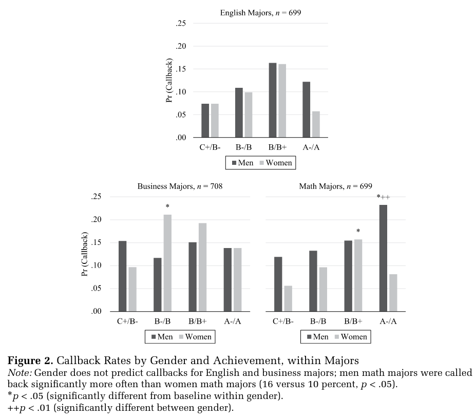

## En los contextos sociales relacionales…

1. **Categorización de sexo** automática e inconsciente: suele ser la primera categoría con que clasificamos.
2. **El género opera “de fondo”**: otras identidades (jefa, empleado) están al frente, y el género sesga cómo se ejercen.

## Cuándo el género es efectivamente destacado (*salient*)

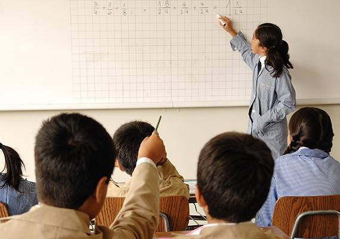

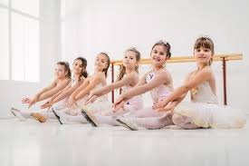

- **Situaciones mixtas:** cuando los actores reales o implicados son de diferente categoría sexual.
- Situaciones en contextos **tipificados por género**: cuando los estereotipos de un género u otro están culturalmente vinculados a las actividades centrales de la situación.

## Expectation states theory

(Berger et al. 1977; Correll & Ridgeway 2003; Ridgeway & Correll 2004)

- Las creencias de estatus moldean las **expectativas de competencia** propias y ajenas, que operan como **profecías autocumplidas**.
- Afectan cuánto aporta cada quien y cómo se valora ese aporte.
- **Doble estándar**: con igual desempeño, a los hombres se les atribuye más habilidad.
  - Las mujeres deben rendir más para ser evaluadas igual (pero no tanto → Quadlin).

## Un “peso en la balanza” que se acumula

(Ridgeway & Correll 2004)

- Efectos **pequeños** en cada situación, pero **acumulativos** a lo largo de la vida.
- La jerarquía **persiste** aunque cambie el contenido de lo que hacen hombres y mujeres.
- Se **reescribe** en ocupaciones e industrias nuevas.
- Discriminación y “elecciones” están **entrelazadas** (Correll 2001).

## La hipótesis de incongruencia de estatus

(Rudman, Moss-Racusin, Phelan & Nauts 2012)

- **Doble vínculo:** sin agencia no parecen calificadas; con agencia sufren *backlash*.
- No se las sanciona por poco amables, sino por **violar la jerarquía de estatus**.
- El *backlash* **defiende el orden de género**: lo ejercen mujeres y hombres.

## Reglas de género y estatus

(Rudman et al. 2012, Estudio 1)

|  | **Prescripciones** (*deben* ser) | **Proscripciones** (*no deben* ser) |
| --- | --- | --- |
| **Mujeres** | Comunales. *Estatus mixto.* | Dominantes. *Alto estatus.* |
| **Hombres** | Agénticos. *Alto estatus.* | Débiles. *Bajo estatus.* |

- Las reglas de género son, en buena medida, **reglas de estatus**.

# Interseccionalidad: ¿de qué hombres y mujeres hablamos?

## Teorías “blanqueadas”

(Chavez & Wingfield 2018)

- Las teorías de la interacción generizada tratan el género **aislado de la raza**: en la práctica describen a personas blancas (*“white-washed”*).
- Dos maneras de incorporar la raza:
  1. **Constructos separados** (doble riesgo, activación alternada).
  2. **Prototipicalidad interseccional**: género y raza **se superponen implícitamente**.

## Prototipicalidad interseccional

(Chavez & Wingfield 2018)

- El género está **racializado** y la raza está **generizada**.
- Quienes no son prototípicos (en EE.UU., mujeres negras y hombres asiáticos) enfrentan “**ataduras y libertades**”:

**Ataduras**

Invisibilidad social, más acoso, penalización afectiva.

**Libertades**

Menos *backlash* por dominancia para líderes negras (Livingston et al. 2012).

# Experiencias trans como lente analítico

## Just one of the guys?

Kristen Schilt (2011)

- **54 entrevistas** con hombres trans sobre sus experiencias laborales, en Texas y California.
- Distintas situaciones: mismo trabajo, nuevos trabajos conocidos como hombres o como trans.
- Estrategias: *open* (públicamente trans) y *stealth* (“disimulo”).

## Just one of the guys?

Kristen Schilt (2011)

- Posición única de moverse a una categoría de género que tiene mayor estatus y ventajas sociales, culturales y económicas.
- **¿Qué significa “alcanzar la hombría social” (*achieving social maleness*)? ¿Cómo se relaciona con el cuerpo? ¿Y de qué manera es un proceso interaccional?**

[figure not shown]

## Hallazgos de Schilt (2011)

1. **Hacer género:** cambia el contacto físico apropiado; cambios corporales para alcanzar la hombría social.
2. **Privilegio masculino:** el mismo comportamiento se valora distinto; opiniones más válidas; no sentir miedo en la noche.
3. **Desventaja masculina:** ser vistos como amenaza para mujeres, segregados de espacios femeninos.

## Hacer género es hacer heteronormatividad

(Schilt & Westbrook 2009)

- La heterosexualidad requiere un **binario de cuerpos “opuestos”**.
- En el trabajo, los “**normales de género**” suelen incorporar a los hombres trans.
- En lo sexual se exige que el género **coincida con los genitales**; la “falla” se sanciona de forma generizada.

Aviso: este artículo incluye contenido sensible sobre violencia.

## Síntesis: lentes sobre la interacción

| Enfoque | Pregunta central | Mecanismo | Límite |
| --- | --- | --- | --- |
| **Hacer género** (West y Zimmerman) | ¿Cómo se produce la diferencia? | Rendición de cuentas | Poco predictivo; difícil explicar el cambio |
| **Estados de expectativa** (Ridgeway y Correll) | ¿Cuándo y cuánto pesa el género? | Creencias de estatus → profecías autocumplidas | Supone creencias hegemónicas “blancas” |
| **Incongruencia de estatus** (Rudman et al.) | ¿Por qué se sanciona a quien rompe la norma? | Defensa de la jerarquía (*backlash*) | Evidencia de laboratorio, muestras blancas |
| **Prototipicalidad interseccional** (Chavez y Wingfield) | ¿A quién aplican estas teorías? | Superposición implícita raza-género | Poca evidencia de interacciones reales |
| **Heteronormatividad** (Schilt y Westbrook) | ¿Qué sostiene el binario? | Exigencia de cuerpos “opuestos” en lo sexual | Centrado en EE.UU. |